# ADP3

## 13.8 Model fitting

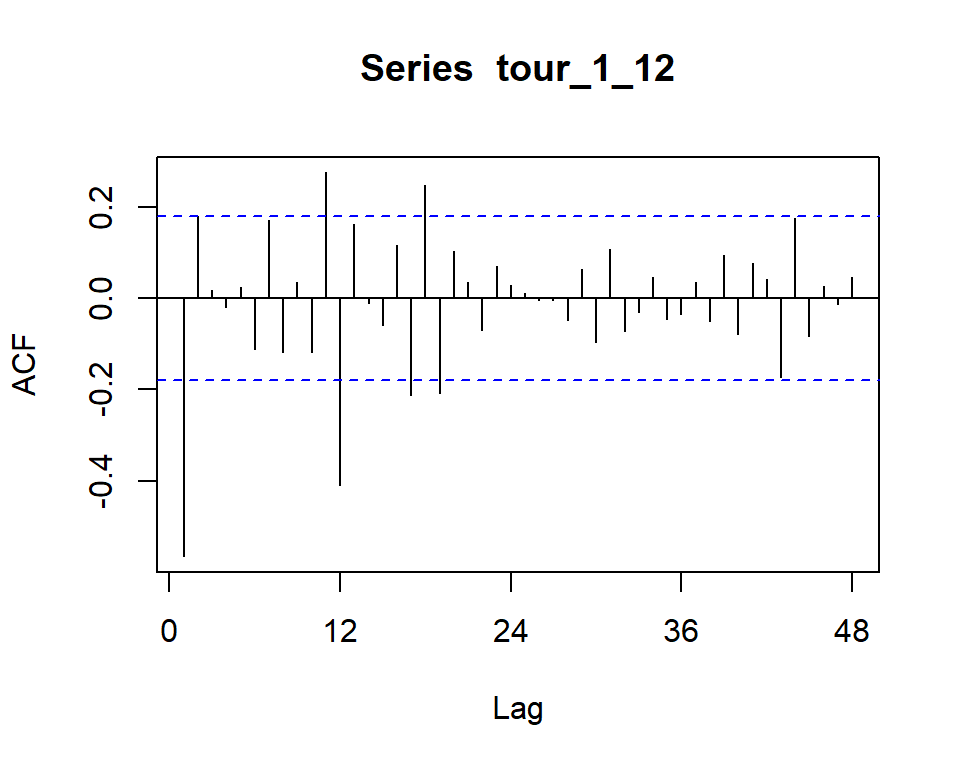

```r
Acf(tour_1_12, lag.max = 48)
```

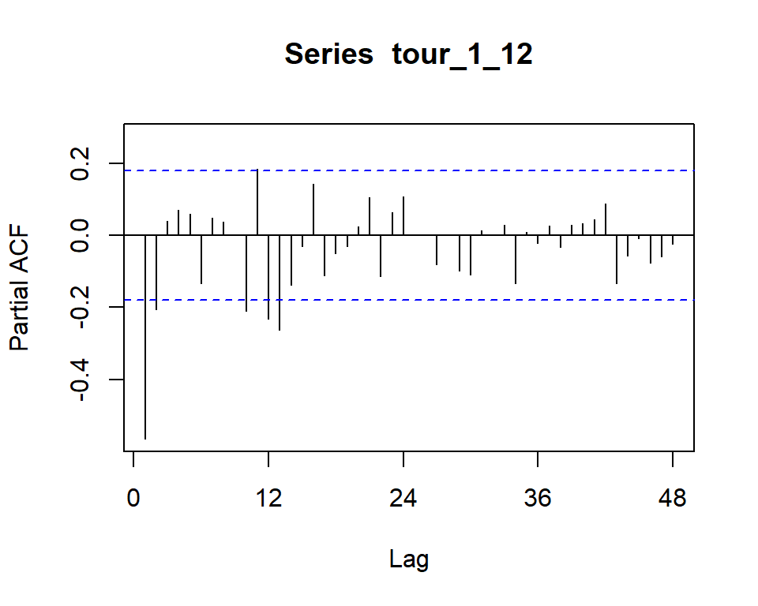

```r
Pacf(tour_1_12, lag.max = 48)
```

비계절형 요소

- ACF 절단, PACF 감소 : p = 0, q = 1
- ACF 감소, PACF 절단 : p = 2, q = 0

계절형 확인 방법

$AR(1)_{12}$

- ACF : 계절주기 12의 배수에 해당하는 시차에 따라 지수적으로 감소
- PACF : 시차 12에서만 값을 갖고 그 이외의 사차에서는 0

$MA(1)_{12}$

- ACF : 시차 12에서만 값을 갖고 그 이외의 사차에서는 0
- PACF : 계절주기 12의 배수에 해당하는 시차에 따라 지수적으로 감소

$ARMA(1, 1)_{12}$

- ACF : 12시차 이후부터 계절주기 12의 배수의 해당되는 시차에 따라 지수적으로 감소
- PACF : 12시차 이후부터 계절주기 12의 배수의 해당되는 시차에 따라 지수적으로 감소

계절형 확인

- ACF 12차 근처에서만 유의적 : P = 0, Q = 1
- PACF 12차 근처에서만 유의적 : P = 1, Q = 0

비계절형 확인

- ACF 절단, PACF 감소 : p = 0, q = 1
- ACF 감소, PACF 절단 : p = 2, q = 0

최종 후보 모형

- $ARIMA(0, 1, 1)(0, 1, 1)_{12}$
- $ARIMA(0, 1, 1)(1, 1, 0)_{12}$
- $ARIMA(2, 1, 0)(0, 1, 1)_{12}$
- $ARIMA(2, 1, 0)(1, 1, 0)_{12}$

$ARIMA(0, 1, 1)(0, 1, 1)_{12}$

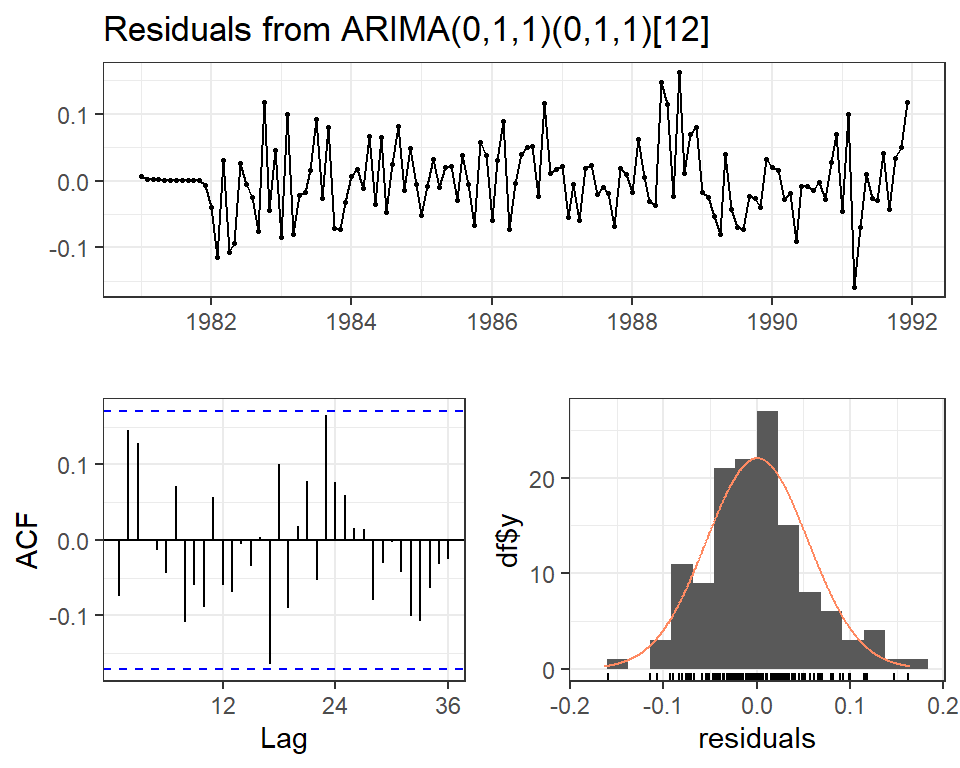

```
##
##  Ljung-Box test
##
## data:  Residuals from ARIMA(0,1,1)(0,1,1)[12]
## Q* = 26.06, df = 22, p-value = 0.2491
##
## Model df: 2.   Total lags used: 24
```

```r
fit1 <- Arima(lntour, order = c(0, 1, 1),
              seasonal = list(order = c(0, 1, 1), period = 12))

checkresiduals(fit1)
```

## 13.9 과대 적합 확인

$ARIMA(0, 1, 1)(0, 1, 1)_{12}$

```r
fit1_1 <- Arima(lntour, order = c(1, 1, 1),
              seasonal = list(order = c(0, 1, 1), period = 12))

fit1_2 <- Arima(lntour, order = c(0, 1, 2),
              seasonal = list(order = c(0, 1, 1), period = 12))
confint(fit1)
```

```
##           2.5 %     97.5 %
## ma1  -0.7168817 -0.4432093
## sma1 -0.7075792 -0.3973742
```

```r
confint(fit1_1) # 추가된 모수 유의적
```

```
##           2.5 %      97.5 %
## ar1  -0.6141189 -0.07646367
## ma1  -0.6019970 -0.07213300
## sma1 -0.6757900 -0.36348852
```

```r
confint(fit1_2) # 추가된 모수 유의적
```

```
##            2.5 %     97.5 %
## ma1  -0.84863210 -0.5006825
## ma2   0.04584469  0.4197128
## sma1 -0.67412800 -0.3580535
```

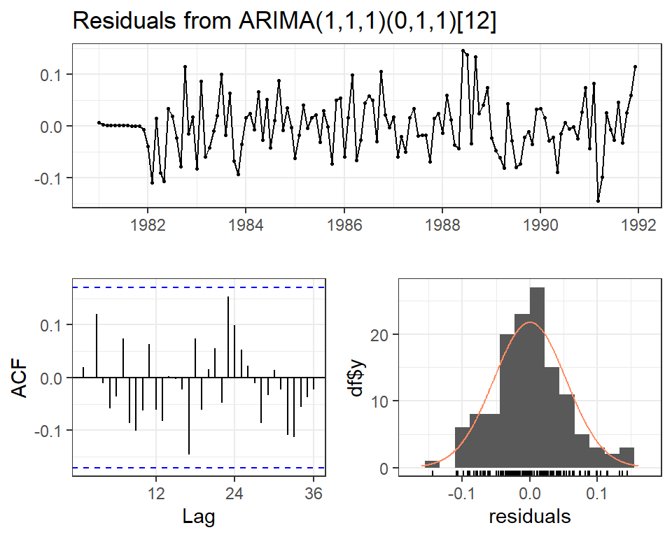

```
##
##  Ljung-Box test
##
## data:  Residuals from ARIMA(1,1,1)(0,1,1)[12]
## Q* = 19.807, df = 21, p-value = 0.5335
##
## Model df: 3.   Total lags used: 24
```

```r
checkresiduals(fit1_1)
```

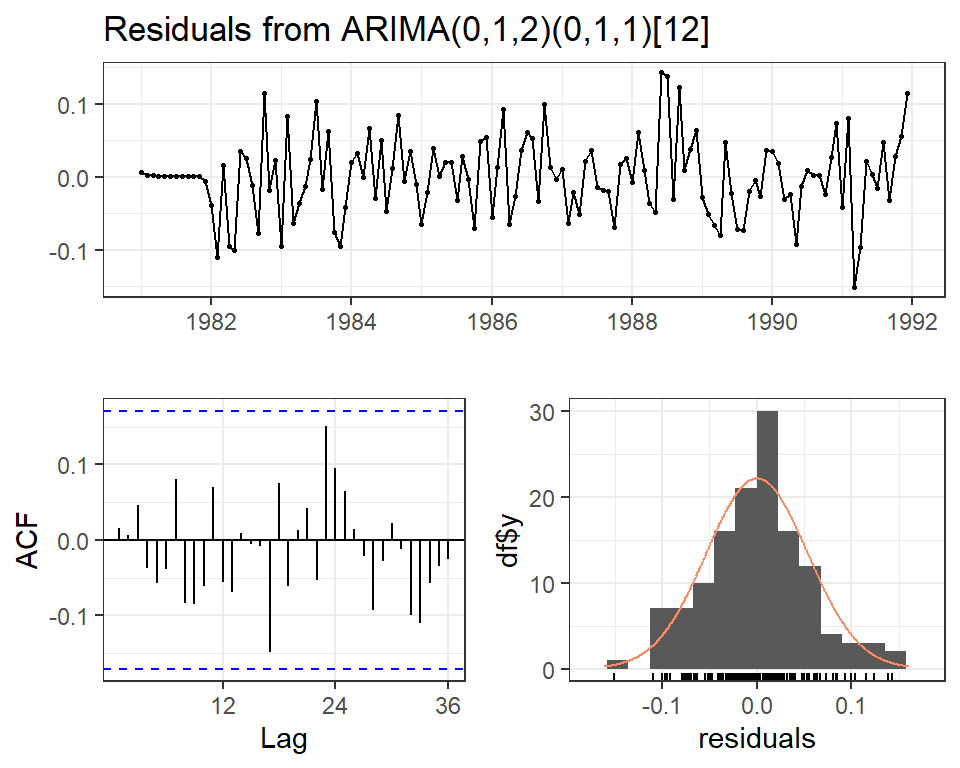

```
##
##  Ljung-Box test
##
## data:  Residuals from ARIMA(0,1,2)(0,1,1)[12]
## Q* = 17.468, df = 21, p-value = 0.6824
##
## Model df: 3.   Total lags used: 24
```

```r
checkresiduals(fit1_2)
```

```r
confint(Arima(lntour, order = c(1, 1, 2),
              seasonal = list(order = c(0, 1, 1), period = 12))) # 추가된 모수 비유의
```

```
##           2.5 %      97.5 %
## ar1  -0.7576853  0.48124313
## ma1  -1.1513542  0.05538992
## ma2  -0.2314544  0.55715140
## sma1 -0.6724509 -0.35743032
```

```r
confint(Arima(lntour, order = c(2, 1, 1),
              seasonal = list(order = c(0, 1, 1), period = 12))) # 추가된 모수 비유의
```

```
##           2.5 %      97.5 %
## ar1  -1.4005757  0.05563757
## ar2  -0.6505574  0.21547715
## ma1  -0.7633223  0.73372547
## sma1 -0.6770033 -0.36266535
```

```r
confint(Arima(lntour, order = c(0, 1, 3),
              seasonal = list(order = c(0, 1, 1), period = 12))) # 추가된 모수 비유의
```

```
##            2.5 %     97.5 %
## ma1  -0.88113628 -0.5041239
## ma2   0.03417003  0.5055626
## ma3  -0.24727265  0.1398392
## sma1 -0.67243530 -0.3582209
```

```r
# fit1_1, fit1_2 예측에 사용 가능
```

$ARIMA(0, 1, 1)(1, 1, 0)_{12}$

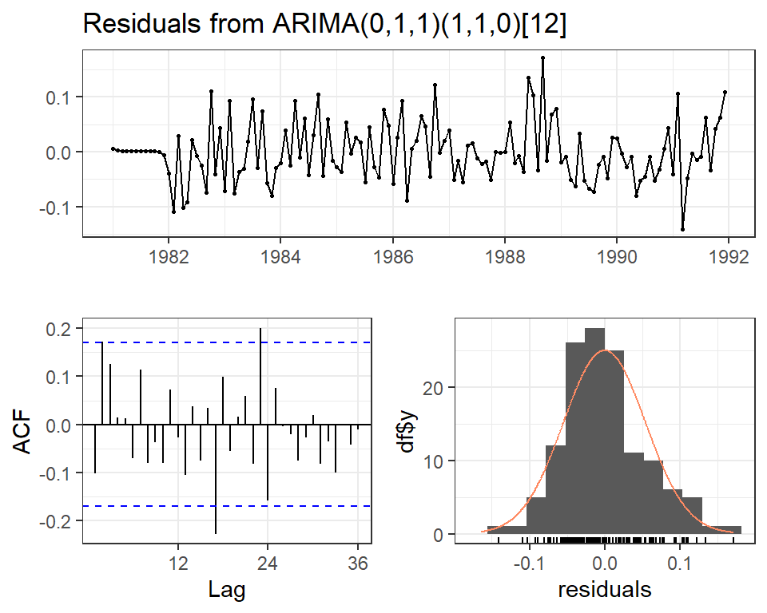

```
##
##  Ljung-Box test
##
## data:  Residuals from ARIMA(0,1,1)(1,1,0)[12]
## Q* = 38.217, df = 22, p-value = 0.01732
##
## Model df: 2.   Total lags used: 24
```

```r
fit2 <- Arima(lntour, order = c(0, 1, 1),
              seasonal = list(order = c(1, 1, 0), period = 12))

checkresiduals(fit2) # 백색잡음 오차 가정 위반
```

## 13.10 과대적합

$ARIMA(0, 1, 1)(1, 1, 0)_{12}$

```r
fit2_1 <- Arima(lntour, order = c(1, 1, 1),
              seasonal = list(order = c(1, 1, 0), period = 12))
fit2_2 <- Arima(lntour, order = c(0, 1, 2),
              seasonal = list(order = c(1, 1, 0), period = 12))
confint(fit2_1) # 추가된 모수 유의
```

```
##           2.5 %     97.5 %
## ar1  -0.6244618 -0.1257088
## ma1  -0.6016499 -0.1026214
## sar1 -0.6862031 -0.3682476
```

```r
confint(fit2_2) # 추가된 모수 유의
```

```
##            2.5 %     97.5 %
## ma1  -0.88940432 -0.5453766
## ma2   0.08103535  0.4425904
## sar1 -0.68381121 -0.3633908
```

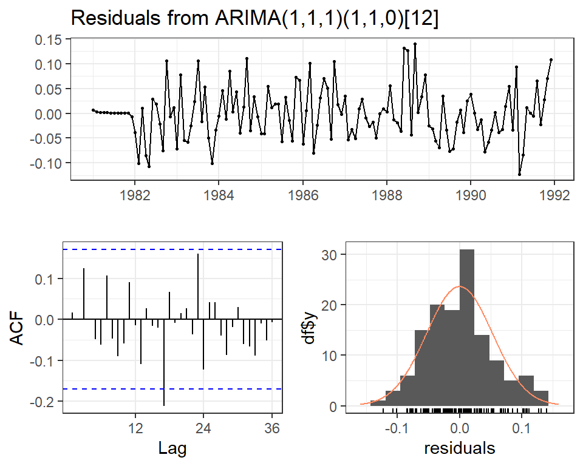

```
##
##  Ljung-Box test
##
## data:  Residuals from ARIMA(1,1,1)(1,1,0)[12]
## Q* = 24.433, df = 21, p-value = 0.2726
##
## Model df: 3.   Total lags used: 24
```

```r
checkresiduals(fit2_1)
```

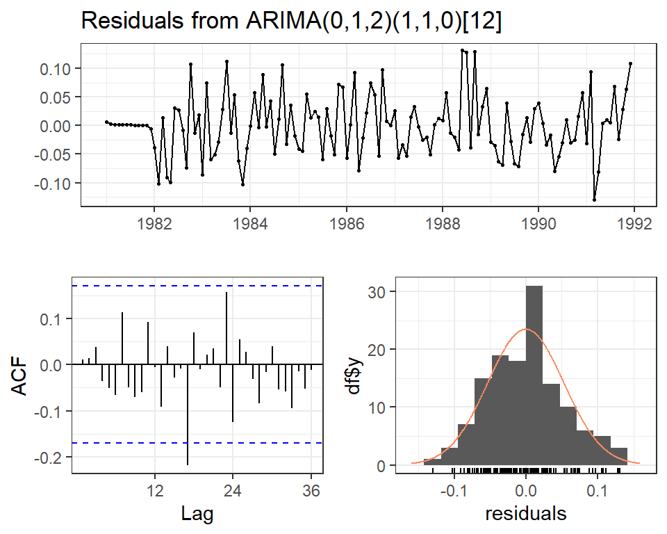

```
##
##  Ljung-Box test
##
## data:  Residuals from ARIMA(0,1,2)(1,1,0)[12]
## Q* = 22.927, df = 21, p-value = 0.3479
##
## Model df: 3.   Total lags used: 24
```

```r
checkresiduals(fit2_2)
```